# Background

This analysis builds upon previous results, utilizing the Boston Housing data to advise a real estate brokerage firm on market value. Using all available variables, except neighborhood, this analysis explores predicting home value through various regression and tree-based methods. Ultimately, one final model is chosen and recommended to the real estate brokerage firm, with commentary provided on model results and important variables.

# Data Initiation

To begin the analysis, we start by loading packages and reading in our data.

```python
RANDOM_SEED = 42

# import packages
import pandas as pd
import numpy as np
import matplotlib.pyplot as plt
import seaborn as sns
import warnings

# for model building and results
from sklearn.linear_model import LinearRegression, Ridge, Lasso, ElasticNet
from sklearn.metrics import make_scorer, mean_squared_error, r2_score, mean_absolute_error
from math import sqrt
from sklearn.model_selection import cross_validate, cross_val_score, cross_val_predict, train_test_split
from sklearn.preprocessing import StandardScaler
from sklearn.ensemble import RandomForestRegressor, GradientBoostingRegressor

# for display
from prettytable import PrettyTable
```

```python
# read in our data
boston_df = pd.read_csv('boston.csv')
boston_df = boston_df.loc[:, boston_df.columns != 'neighborhood'] #remove this right away

boston_df.info()
boston_df.describe() #do see that there is a range in values
#boston_df["neighborhood"].unique() #let's explore neighborhood - there are 93 distinct vals!
```

```
<class 'pandas.core.frame.DataFrame'>
RangeIndex: 506 entries, 0 to 505
Data columns (total 13 columns):
crim       506 non-null float64
zn         506 non-null float64
indus      506 non-null float64
chas       506 non-null int64
nox        506 non-null float64
rooms      506 non-null float64
age        506 non-null float64
dis        506 non-null float64
rad        506 non-null int64
tax        506 non-null int64
ptratio    506 non-null float64
lstat      506 non-null float64
mv         506 non-null float64
dtypes: float64(10), int64(3)
memory usage: 51.5 KB
```

|  | crim | zn | indus | chas | nox | rooms | age | dis | rad | tax | ptratio | lstat | mv |
| --- | --- | --- | --- | --- | --- | --- | --- | --- | --- | --- | --- | --- | --- |
| count | 506.000000 | 506.000000 | 506.000000 | 506.000000 | 506.000000 | 506.000000 | 506.000000 | 506.000000 | 506.000000 | 506.000000 | 506.000000 | 506.000000 | 506.000000 |
| mean | 3.613524 | 11.363636 | 11.136779 | 0.069170 | 0.554695 | 6.284634 | 68.574901 | 3.795043 | 9.549407 | 408.237154 | 18.455534 | 12.653063 | 22.528854 |
| std | 8.601545 | 23.322453 | 6.860353 | 0.253994 | 0.115878 | 0.702617 | 28.148861 | 2.105710 | 8.707259 | 168.537116 | 2.164946 | 7.141062 | 9.182176 |
| min | 0.006320 | 0.000000 | 0.460000 | 0.000000 | 0.385000 | 3.561000 | 2.900000 | 1.129600 | 1.000000 | 187.000000 | 12.600000 | 1.730000 | 5.000000 |
| 25% | 0.082045 | 0.000000 | 5.190000 | 0.000000 | 0.449000 | 5.885500 | 45.025000 | 2.100175 | 4.000000 | 279.000000 | 17.400000 | 6.950000 | 17.025000 |
| 50% | 0.256510 | 0.000000 | 9.690000 | 0.000000 | 0.538000 | 6.208500 | 77.500000 | 3.207450 | 5.000000 | 330.000000 | 19.050000 | 11.360000 | 21.200000 |
| 75% | 3.677082 | 12.500000 | 18.100000 | 0.000000 | 0.624000 | 6.623500 | 94.075000 | 5.188425 | 24.000000 | 666.000000 | 20.200000 | 16.955000 | 25.000000 |
| max | 88.976200 | 100.000000 | 27.740000 | 1.000000 | 0.871000 | 8.780000 | 100.000000 | 12.126500 | 24.000000 | 711.000000 | 22.000000 | 37.970000 | 50.000000 |

```python
# is there missing data?
print(boston_df.isnull().sum())
# from the output below, there is no missing data
```

```
crim       0
zn         0
indus      0
chas       0
nox        0
rooms      0
age        0
dis        0
rad        0
tax        0
ptratio    0
lstat      0
mv         0
dtype: int64
```

From the output above, we can see that we have twelve variables of numeric value and none of them have missing values. However, we can see that there is a range in some of the values. For instance, the nox (air pollution) variable has a small range in values, whereas the tax rate variable has a wide range in values. This observation is key to consider when building certain models, as scaling the data may be necessary.

# Exploratory Data Analysis

No exploratory data analysis results are shown in this analysis, as the prior analysis contained this information. Therefore, this information is omitted to help with brevity.

# Model Building

In this section, we compare and contrast results from the methods employed to build models last time (linear, ridge, and lasso regression), along with some tree based methods (random forest and gradient boosting).

It is important to note that the regression methods will utilize a standardized data set, while the tree based methods will use the raw Boston housing data set. All results displayed in this section are on the training data sets only. Where possible, cross validation is used to share initial model results and tune hyperparameters.

We split our data sets into training and testing sets using an 80/20 split. Additionally, functions are defined for goodness of fit metrics and alpha tuning for the ridge and lasso regression models.

```python
current_palette = sns.color_palette() #10 colors

X, y = boston_df.loc[:, ~boston_df.columns.isin(['mv'])], boston_df['mv']
X_train, X_test, y_train, y_test = train_test_split(X, y, test_size=0.20, random_state=RANDOM_SEED)

y_train = np.array(y_train).reshape(-1,1)
y_test = np.array(y_test).reshape(-1,1)

scalerX = StandardScaler().fit(np.array(X_train).reshape(-1,1))
scalery = StandardScaler().fit(y_train)
X_train = scalerX.transform(X_train)
y_train = scalery.transform(y_train)
X_test = scalerX.transform(X_test)
y_test = scalery.transform(y_test)

#quick check the size of our new data frames
print(X_train.shape, y_train.shape)
print(X_test.shape, y_test.shape)
```

```
(404, 12) (404, 1)
(102, 12) (102, 1)
```

```python
#calculate GOF metrics as a summary
def gof_sum(yhat, y, model_name, main_title):
    rsquared = round(r2_score(y, yhat),3)
    mse = mean_squared_error(y, yhat)
    rmse = round(sqrt(mse),3)
    mse = round(mse,3)
    mae = round(mean_absolute_error(y, yhat),3)

    x = PrettyTable()
    x.field_names = ["Model", "R-Squared", "MSE", "RMSE", "MAE"]
    x.add_row([model_name, rsquared, mse, rmse, mae])
    print(x.get_string(title=main_title))
```

```python
#in reading documentation on cross val metrics, only neg_mean_squared_error is one
#therefore, best to create our own metric and call that using cross_val_score
from sklearn.metrics import make_scorer
def rmse(y, yhat):
        return np.sqrt(np.mean((yhat - y)**2))

rmse_scorer = make_scorer(rmse, greater_is_better=False)
```

```python
#function for alpha tuning
def alpha_tuning(model):
    alphas = [0.0001, 0.001, 0.01, 0.1, 1, 10]
    val_errors = []
    for alpha in alphas:
        m_minmax = model(alpha=alpha, fit_intercept=True, random_state=RANDOM_SEED)
        errors = np.sum(-cross_val_score(m_minmax,
                                     X_train,
                                     y_train,
                                     scoring='neg_mean_squared_error',
                                     cv=10,
                                     n_jobs=-1))
        val_errors.append(np.sqrt(errors))
    print('best alpha: {}'.format(alphas[np.argmin(val_errors)]))
```

## Linear Regression

First, we fit a linear regression model and then evaluate results using 10-fold cross-validation. RMSE is the metric used to evaluate performance. The linear regression model is really the baseline model.

```python
lin_reg = LinearRegression()
lin_reg.fit(X_train, y_train)

#run the cross validation
score = cross_val_score(lin_reg, X_train, y_train, cv=10, scoring=rmse_scorer)
print("CV RMSE results: ", -1 * score)
print("CV RMSE mean: ", -1 * np.mean(score))
```

```
CV RMSE results:  [0.4287949  0.45667568 0.5915989  0.70491578 0.49234185 0.54788698
 0.50428097 0.47939429 0.42803183 0.6011002 ]
CV RMSE mean:  0.5235021373403351
```

From the cross validation results above, we can see that the mean RMSE across the 10-folds is .523. However, we can see that there is variability in the performance across the folds, as the range is from .428 to .704. These results will become more meaningful as we generate results from other methods. As it stands, we are merely just trying to gauge the performance of this model on data it has not seen before.

Next, we examine traditional goodness of fit statistics to determine the performance of this model.

```python
#get linear regression gof
lin_reg_yhat = lin_reg.predict(X_train)
gof_sum(lin_reg_yhat, y_train, "Linear Regression", "Training Set")
```

```
+-------------------------------------------------------+
|                      Training Set                     |
+-------------------+-----------+-------+-------+-------+
|       Model       | R-Squared |  MSE  |  RMSE |  MAE  |
+-------------------+-----------+-------+-------+-------+
| Linear Regression |   0.745   | 0.255 | 0.505 | 0.363 |
+-------------------+-----------+-------+-------+-------+
```

It is worth pointing out that because our variables were centered and scaled, then the resulting goodness of fit statistics are scaled as well and not interpreted in thousands of 1970s dollars.

From the goodness of fit statistics table above, we can see that the R-squared value is fairly high at .745. However, we can see that there are differences in MAE and RMSE. For background, MAE is the average magnitude of errors, while the RMSE takes the square root of the squared difference between the residuals and fitted values. Therefore, RMSE gives more weight to values that are farther away from their actual value. If MAE and RMSE are close together or about equal, then we know that all the errors are of the same magnitude.

In our case, MAE and RMSE are not equal, which tells us that not all errors are of the same magnitude. As a step to improve model fit, residuals could be examined in greater detail to determine if there are influential points that should be removed.

## Ridge Regression

Next, we generate a model using ridge regression. Ridge regression utilizes an L2 regularization, which is an additional constraint that helps with overfitting. In this model, the magnitude of the coefficients should be as small as possible.

Like with the linear regression model, we evaluate initial model performance using 10-fold cross validation.

```python
ridge = Ridge(alpha=1)
ridge.fit(X_train, y_train)

#run the cross validation
score = cross_val_score(ridge, X_train, y_train, cv=10, scoring=rmse_scorer)
print("CV RMSE results: ", -1 * score)
print("CV RMSE mean: ", -1 * np.mean(score))
```

```
CV RMSE results:  [0.66825044 0.69463075 0.86781408 0.5815557  0.78634357 0.72174601
 0.85330281 0.59992034 0.62867258 0.72842949]
CV RMSE mean:  0.7130665785708075
```

From the default ridge regression model (alpha = 1), we can see that the CV RMSE results are very similar to the linear regression results in that there is a wide range of values. However, the mean RMSE is higher for this model compared to the linear regression model. Hopefully, a better alpha parameter will change this result.

We now examine the optimal ridge regression model by adjusting the alpha parameter. As the alpha parameter increases, coefficients move toward zero. Adjusting this parameter impacts training and test set performance. Therefore, we utilize a grid and select the best alpha that yields the smallest mean RMSE on a cross validation fold.

```python
alpha_tuning(Ridge) #best alpha is .0001
```

```
best alpha: 0.0001
```

From the tuning results, we can see that the best alpha has a value of .0001. Therefore, we redefine the ridge regression model to have an alpha value of .0001.

```python
#redefine Ridge using alpha from above
ridge = Ridge(alpha=.0001)
ridge.fit(X_train, y_train)
```

```
Ridge(alpha=0.0001, copy_X=True, fit_intercept=True, max_iter=None,
   normalize=False, random_state=None, solver='auto', tol=0.001)
```

```python
#run the cross validation
score = cross_val_score(ridge, X_train, y_train, cv=10, scoring=rmse_scorer)
print("CV RMSE results: ", -1 * score)
print("CV RMSE mean: ", -1 * np.mean(score))
```

```
CV RMSE results:  [0.44097184 0.46748839 0.59432952 0.70648019 0.48106207 0.55634098
 0.49972987 0.48321555 0.43915666 0.60449407]
CV RMSE mean:  0.5273269145939519
```

Next, we examine some goodness of fit statistics.

```python
#get ridge gof
ridge_yhat = ridge.predict(X_train)
gof_sum(ridge_yhat, y_train, "Ridge Regression", "Training Set")
```

```
+------------------------------------------------------+
|                     Training Set                     |
+------------------+-----------+-------+-------+-------+
|      Model       | R-Squared |  MSE  |  RMSE |  MAE  |
+------------------+-----------+-------+-------+-------+
| Ridge Regression |   0.741   | 0.259 | 0.509 | 0.363 |
+------------------+-----------+-------+-------+-------+
```

From the goodness of fit statistics table, we can see that the ridge regression model perfors similarly on the training set compared to the linear regression model, although its results are slightly worse. This result makes sense because this model helps to protect against overfitting. It will be important to see if the performance between these two models varies on the test set.

## Lasso Regression

An alternative model to ridge regression is lasso regression. This model uses an L1 regularization, which is more restrictive and creates some coefficients that are exactly zero. This type of model can be beneficial when there are a lot of predictors and only a few are thought to be important.

```python
lasso = Lasso(alpha=1)
lasso.fit(X_train,y_train)

#run the cross validation
score = cross_val_score(lasso, X_train, y_train, cv=10, scoring=rmse_scorer)
print("CV RMSE results: ", -1 * score)
print("CV RMSE mean: ", -1 * np.mean(score))
```

```
CV RMSE results:  [0.87620142 1.00563463 1.18642309 0.87365435 1.07366931 1.0609493
 1.22489433 0.84041962 0.89251147 0.89491748]
CV RMSE mean:  0.9929275009380228
```

From the default lasso model, we can see that the CV RMSE results are way worse than the ridge and linear regression models. Therefore, it is likely that a different alpha parameter is needed to experience better training set results.

Similar to the ridge model, we utilize a grid to determine the best alpha parameter using 10-fold cross validation.

```python
alpha_tuning(Lasso) #best alpha is .0001
```

```
best alpha: 0.0001
```

```python
#redefine Lasso using alpha from above
lasso = Lasso(alpha=.0001)
lasso.fit(X_train, y_train)
```

```
Lasso(alpha=0.0001, copy_X=True, fit_intercept=True, max_iter=1000,
   normalize=False, positive=False, precompute=False, random_state=None,
   selection='cyclic', tol=0.0001, warm_start=False)
```

```python
#get lasso gof
lasso_yhat = lasso.predict(X_train)
gof_sum(lasso_yhat, y_train, "Lasso Regression", "Training Set")
```

```
+------------------------------------------------------+
|                     Training Set                     |
+------------------+-----------+-------+-------+-------+
|      Model       | R-Squared |  MSE  |  RMSE |  MAE  |
+------------------+-----------+-------+-------+-------+
| Lasso Regression |   0.731   | 0.269 | 0.519 | 0.369 |
+------------------+-----------+-------+-------+-------+
```

From the goodness of fit table above, we can see that the performance metrics are very similar to both the linear and ridge regression models, although the R-squred is slightly lower and other metrics are slightly higher. The lasso model has a stronger regularization parameter so these results are in line with what we would expect.

It is too close to hypothesize which model may have better test set performance, although we are hoping to see that one of the regularized models performs better.

## Random Forest

In this section, we create a model using a random forest. A random forest is a collection of decision trees that injects randomness in the tree-building process. This randomness occurs by varying the variables considered in each tree and varying the data included to build the tree. By generating multiple random trees, this model is able to better discern nuances within the data and protect against overfitting.

We build the random forest on the raw boston housing dataset, as variable standardization has no impact on model performance.

```python
X2, y2 = boston_df.loc[:, ~boston_df.columns.isin(['mv'])], boston_df['mv']
X_train2, X_test2, y_train2, y_test2 = train_test_split(X2, y2, test_size=0.20, random_state=RANDOM_SEED)
```

One of the critical components of the random forest model is the hyperparameters used to build the tree. For instance, one hyperparameter involves defining the number of trees in the forest. Having too few trees can be disadvantageous, but generally there is a point where increasing the number of trees does not impact model performance. A few other key hyperparameters are included in scope for tuning, such as tree depth, the number of variables each tree can consider at each split, and how the model evaluates the best split.

This parameter grid will help to inform the best model to use for the random forest. Similar to the alpha tuning for the regression models above, the best parameters are selected on the basis of mean RMSE. Here, only 5-fold cross-validation is used to help with time, given there are more parameters in scope for tuning.

```python
import warnings
warnings.simplefilter(action='ignore', category=DeprecationWarning)

#we determine best params for rf model using grid search below
#this takes some time to run
#5-fold CV is used to help with time
rf = RandomForestRegressor(random_state = RANDOM_SEED, n_jobs=-1)
from sklearn.model_selection import GridSearchCV

param_grid = {
    'n_estimators': [500, 1000, 1500, 2000],
    'max_features': ['auto', 'log2'],
    'max_depth' : [2,5,7],
    'criterion' :['mse', 'mae']
}

#train model
#use custom rmse_scorer to get CV results using RMSE
CV_rf = GridSearchCV(estimator = rf, param_grid = param_grid, cv = 5, scoring=rmse_scorer, return_train_score=True)
CV_rf.fit(X_train2, y_train2)
```

```
GridSearchCV(cv=5, error_score='raise-deprecating',
       estimator=RandomForestRegressor(bootstrap=True, criterion='mse', max_depth=None,
           max_features='auto', max_leaf_nodes=None,
           min_impurity_decrease=0.0, min_impurity_split=None,
           min_samples_leaf=1, min_samples_split=2,
           min_weight_fraction_leaf=0.0, n_estimators='warn', n_jobs=-1,
           oob_score=False, random_state=42, verbose=0, warm_start=False),
       fit_params=None, iid='warn', n_jobs=None,
       param_grid={'n_estimators': [500, 1000, 1500, 2000], 'max_features': ['auto', 'log2'], 'max_depth': [2, 5, 7], 'criterion': ['mse', 'mae']},
       pre_dispatch='2*n_jobs', refit=True, return_train_score=True,
       scoring=make_scorer(rmse, greater_is_better=False), verbose=0)
```

```python
#grab the best parameters
CV_rf.best_params_
```

```
{'criterion': 'mse',
 'max_depth': 7,
 'max_features': 'log2',
 'n_estimators': 500}
```

From this output, we can easily grab the best parameters, which are defined above. However, we can view the mean RMSE output across all parameter combinations (48 in total) below. The mean_test_score represents the mean RMSE results. For whatever reason the RMSE results are negative in this context, but its interpretation remains the same (i.e., lower is better).

```python
results = pd.DataFrame(CV_rf.cv_results_)
results[['mean_test_score', 'param_criterion','param_max_depth', 'param_max_features', 'param_n_estimators']].round(3)
```

|  | mean_test_score | param_criterion | param_max_depth | param_max_features | param_n_estimators |
| --- | --- | --- | --- | --- | --- |
| 0 | -4.750 | mse | 2 | auto | 500 |
| 1 | -4.760 | mse | 2 | auto | 1000 |
| 2 | -4.765 | mse | 2 | auto | 1500 |
| 3 | -4.765 | mse | 2 | auto | 2000 |
| 4 | -5.354 | mse | 2 | log2 | 500 |
| 5 | -5.380 | mse | 2 | log2 | 1000 |
| 6 | -5.362 | mse | 2 | log2 | 1500 |
| 7 | -5.379 | mse | 2 | log2 | 2000 |
| 8 | -3.900 | mse | 5 | auto | 500 |
| 9 | -3.899 | mse | 5 | auto | 1000 |
| 10 | -3.908 | mse | 5 | auto | 1500 |
| 11 | -3.901 | mse | 5 | auto | 2000 |
| 12 | -3.891 | mse | 5 | log2 | 500 |
| 13 | -3.866 | mse | 5 | log2 | 1000 |
| 14 | -3.857 | mse | 5 | log2 | 1500 |
| 15 | -3.848 | mse | 5 | log2 | 2000 |
| 16 | -3.817 | mse | 7 | auto | 500 |
| 17 | -3.809 | mse | 7 | auto | 1000 |
| 18 | -3.817 | mse | 7 | auto | 1500 |
| 19 | -3.813 | mse | 7 | auto | 2000 |
| 20 | -3.609 | mse | 7 | log2 | 500 |
| 21 | -3.627 | mse | 7 | log2 | 1000 |
| 22 | -3.631 | mse | 7 | log2 | 1500 |
| 23 | -3.626 | mse | 7 | log2 | 2000 |
| 24 | -4.806 | mae | 2 | auto | 500 |
| 25 | -4.829 | mae | 2 | auto | 1000 |
| 26 | -4.828 | mae | 2 | auto | 1500 |
| 27 | -4.831 | mae | 2 | auto | 2000 |
| 28 | -5.635 | mae | 2 | log2 | 500 |
| 29 | -5.659 | mae | 2 | log2 | 1000 |
| 30 | -5.649 | mae | 2 | log2 | 1500 |
| 31 | -5.669 | mae | 2 | log2 | 2000 |
| 32 | -4.032 | mae | 5 | auto | 500 |
| 33 | -4.033 | mae | 5 | auto | 1000 |
| 34 | -4.042 | mae | 5 | auto | 1500 |
| 35 | -4.042 | mae | 5 | auto | 2000 |
| 36 | -3.887 | mae | 5 | log2 | 500 |
| 37 | -3.905 | mae | 5 | log2 | 1000 |
| 38 | -3.914 | mae | 5 | log2 | 1500 |
| 39 | -3.917 | mae | 5 | log2 | 2000 |
| 40 | -3.927 | mae | 7 | auto | 500 |
| 41 | -3.933 | mae | 7 | auto | 1000 |
| 42 | -3.945 | mae | 7 | auto | 1500 |
| 43 | -3.939 | mae | 7 | auto | 2000 |
| 44 | -3.615 | mae | 7 | log2 | 500 |
| 45 | -3.636 | mae | 7 | log2 | 1000 |
| 46 | -3.629 | mae | 7 | log2 | 1500 |
| 47 | -3.623 | mae | 7 | log2 | 2000 |

Now we define our random forest model using the best parameters found above.

```python
#refit our random forest using the best params above
rf = RandomForestRegressor(n_estimators = 500, max_features = 'log2', max_depth = 7, criterion = 'mse', random_state = RANDOM_SEED, n_jobs=-1)
rf.fit(X_train2, y_train2)
```

```
RandomForestRegressor(bootstrap=True, criterion='mse', max_depth=7,
           max_features='log2', max_leaf_nodes=None,
           min_impurity_decrease=0.0, min_impurity_split=None,
           min_samples_leaf=1, min_samples_split=2,
           min_weight_fraction_leaf=0.0, n_estimators=500, n_jobs=-1,
           oob_score=False, random_state=42, verbose=0, warm_start=False)
```

One of the advantages of random forests is that they are able to inform which variables are important. From a random forest perspective, a variable is deemed more important if it aids in a higher tree accuracy. The accuracy can be measured by permutating values of a variable and determining how much the accuracy decreases. Therefore, more important variables, when permuted, have a larger dip in accuracy. Another way to think of accuracy is more important variables generate tree splits that are more pure or closer to the true value.

In the visual below, variables with a higher importance score are thought to be more important variables.

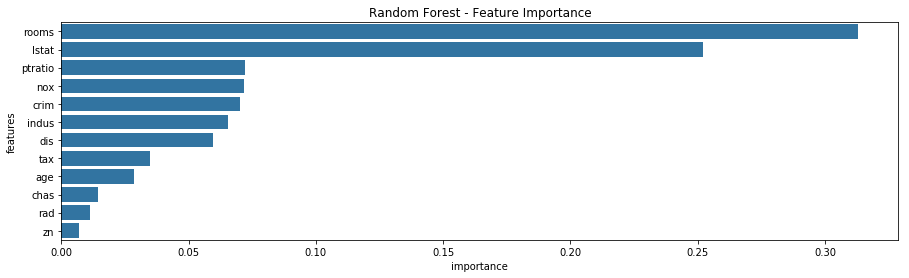

```python
feature_importances = pd.DataFrame(rf.feature_importances_,
                                   index = X_train2.columns,
                                   columns=['importance']).sort_values('importance', ascending=False)
feature_importances['features'] = feature_importances.index

fig, axes = plt.subplots(nrows=1, ncols=1, figsize = (15,4))
sns.barplot(y = 'features', x = 'importance', data = feature_importances, color = current_palette[0])
plt.title('Random Forest - Feature Importance')
```

Therefore, from this variable importance plot, the number of rooms (rooms) and socioeconomic status (lstat) are important indicators for determining median home value. In contrast, variables such as percent of land zoned for lots (zn) and access to radial highways (rad) appear to have a smaller impact on median home value.

Similar to the models above, we evaluate random forest results using goodness of fit statistics.

```python
#model evaluation
rf_yhat = rf.predict(X_train2)
gof_sum(rf_yhat, y_train2, "Random Forest", "Training Set")
```

```
+---------------------------------------------------+
|                    Training Set                   |
+---------------+-----------+-------+-------+-------+
|     Model     | R-Squared |  MSE  |  RMSE |  MAE  |
+---------------+-----------+-------+-------+-------+
| Random Forest |   0.961   | 3.376 | 1.837 | 1.396 |
+---------------+-----------+-------+-------+-------+
```

From the goodness of fit results, we can see that the R-squared value is extremely high. The regression models all had R-squared values around .74. While we cannot readily compare the MSE, RMSE, and MAE values between the random forest model and regression models just yet, these results seem very positive.

## Gradient Tree Boosting

In this section, we will utilize another variant of decision trees called gradient tree boosting. In general, the idea behind boosting is to combine several week learners together into a strong learner. Thus, with gradient boosting, the algorithm works by fitting several decision trees sequentially. Each decision tree fits a new predictor to the residual errors made by the previous predictor, trying to improve upon the overall predictions made. The final predictions are based on the sum of the predictions of all trees.

Similar to the random forest model building process, here we will utilize a parameter grid to tune different hyperparameters for this model. In addition to the normal tree hyperparameters, one other key hyperparameter is the learning rate. The learning rate for gradient tree boosting is akin to the alpha regularization parameter in ridge and lasso regression in that it helps to protect against overfitting by constraining how much each new tree can correct for the previous tree's errors.

```python
gbm = GradientBoostingRegressor(random_state = RANDOM_SEED)

param_grid = {
    'learning_rate': [0.01,.025,0.05,.075,0.1],
    'max_depth': [2,5,7],
    'max_features' : ['log2', 'sqrt'],
    'criterion': ['mse', 'mae'],
}

#train model
#use custom rmse_scorer to get CV results using RMSE
CV_gbm = GridSearchCV(estimator = gbm, param_grid = param_grid, cv = 5, scoring=rmse_scorer, return_train_score=True)
CV_gbm.fit(X_train2, y_train2)
```

```
GridSearchCV(cv=5, error_score='raise-deprecating',
       estimator=GradientBoostingRegressor(alpha=0.9, criterion='friedman_mse', init=None,
             learning_rate=0.1, loss='ls', max_depth=3, max_features=None,
             max_leaf_nodes=None, min_impurity_decrease=0.0,
             min_impurity_split=None, min_samples_leaf=1,
             min_sampl...te=42, subsample=1.0, tol=0.0001,
             validation_fraction=0.1, verbose=0, warm_start=False),
       fit_params=None, iid='warn', n_jobs=None,
       param_grid={'learning_rate': [0.01, 0.025, 0.05, 0.075, 0.1], 'max_depth': [2, 5, 7], 'max_features': ['log2', 'sqrt'], 'criterion': ['mse', 'mae']},
       pre_dispatch='2*n_jobs', refit=True, return_train_score=True,
       scoring=make_scorer(rmse, greater_is_better=False), verbose=0)
```

```python
#grab the best parameters
CV_gbm.best_params_
```

```
{'criterion': 'mse',
 'learning_rate': 0.075,
 'max_depth': 5,
 'max_features': 'log2'}
```

From the parameter grid output, we can easily identify the best parameters, which are defined above. The number of trees were not included in the parameter grid because of time constraints. For this model, 500 trees will be used.

A more informative comparison is examining the mean RMSE output across all parameter combinations (60 in total) below. Like with the random forest output, the mean_test_score represents the mean RMSE results. The RMSE results that are returned are negative, but the RMSE interpretation remains the same (i.e., lower is better).

```python
results2 = pd.DataFrame(CV_gbm.cv_results_)
#results2.info()
results2[['mean_test_score', 'param_criterion','param_max_depth', 'param_max_features', 'param_learning_rate']].round(3)
```

|  | mean_test_score | param_criterion | param_max_depth | param_max_features | param_learning_rate |
| --- | --- | --- | --- | --- | --- |
| 0 | -6.217 | mse | 2 | log2 | 0.01 |
| 1 | -6.217 | mse | 2 | sqrt | 0.01 |
| 2 | -5.104 | mse | 5 | log2 | 0.01 |
| 3 | -5.104 | mse | 5 | sqrt | 0.01 |
| 4 | -4.940 | mse | 7 | log2 | 0.01 |
| 5 | -4.940 | mse | 7 | sqrt | 0.01 |
| 6 | -4.515 | mse | 2 | log2 | 0.025 |
| 7 | -4.515 | mse | 2 | sqrt | 0.025 |
| 8 | -3.578 | mse | 5 | log2 | 0.025 |
| 9 | -3.578 | mse | 5 | sqrt | 0.025 |
| 10 | -3.618 | mse | 7 | log2 | 0.025 |
| 11 | -3.618 | mse | 7 | sqrt | 0.025 |
| 12 | -3.862 | mse | 2 | log2 | 0.05 |
| 13 | -3.862 | mse | 2 | sqrt | 0.05 |
| 14 | -3.302 | mse | 5 | log2 | 0.05 |
| 15 | -3.302 | mse | 5 | sqrt | 0.05 |
| 16 | -3.441 | mse | 7 | log2 | 0.05 |
| 17 | -3.441 | mse | 7 | sqrt | 0.05 |
| 18 | -3.702 | mse | 2 | log2 | 0.075 |
| 19 | -3.702 | mse | 2 | sqrt | 0.075 |
| 20 | -3.243 | mse | 5 | log2 | 0.075 |
| 21 | -3.243 | mse | 5 | sqrt | 0.075 |
| 22 | -3.495 | mse | 7 | log2 | 0.075 |
| 23 | -3.495 | mse | 7 | sqrt | 0.075 |
| 24 | -3.744 | mse | 2 | log2 | 0.1 |
| 25 | -3.744 | mse | 2 | sqrt | 0.1 |
| 26 | -3.282 | mse | 5 | log2 | 0.1 |
| 27 | -3.282 | mse | 5 | sqrt | 0.1 |
| 28 | -3.442 | mse | 7 | log2 | 0.1 |
| 29 | -3.442 | mse | 7 | sqrt | 0.1 |
| 30 | -6.413 | mae | 2 | log2 | 0.01 |
| 31 | -6.413 | mae | 2 | sqrt | 0.01 |
| 32 | -5.120 | mae | 5 | log2 | 0.01 |
| 33 | -5.120 | mae | 5 | sqrt | 0.01 |
| 34 | -4.994 | mae | 7 | log2 | 0.01 |
| 35 | -4.994 | mae | 7 | sqrt | 0.01 |
| 36 | -4.743 | mae | 2 | log2 | 0.025 |
| 37 | -4.743 | mae | 2 | sqrt | 0.025 |
| 38 | -3.570 | mae | 5 | log2 | 0.025 |
| 39 | -3.570 | mae | 5 | sqrt | 0.025 |
| 40 | -3.589 | mae | 7 | log2 | 0.025 |
| 41 | -3.589 | mae | 7 | sqrt | 0.025 |
| 42 | -4.049 | mae | 2 | log2 | 0.05 |
| 43 | -4.049 | mae | 2 | sqrt | 0.05 |
| 44 | -3.406 | mae | 5 | log2 | 0.05 |
| 45 | -3.406 | mae | 5 | sqrt | 0.05 |
| 46 | -3.471 | mae | 7 | log2 | 0.05 |
| 47 | -3.471 | mae | 7 | sqrt | 0.05 |
| 48 | -3.880 | mae | 2 | log2 | 0.075 |
| 49 | -3.880 | mae | 2 | sqrt | 0.075 |
| 50 | -3.313 | mae | 5 | log2 | 0.075 |
| 51 | -3.313 | mae | 5 | sqrt | 0.075 |
| 52 | -3.450 | mae | 7 | log2 | 0.075 |
| 53 | -3.450 | mae | 7 | sqrt | 0.075 |
| 54 | -3.879 | mae | 2 | log2 | 0.1 |
| 55 | -3.879 | mae | 2 | sqrt | 0.1 |
| 56 | -3.396 | mae | 5 | log2 | 0.1 |
| 57 | -3.396 | mae | 5 | sqrt | 0.1 |
| 58 | -3.426 | mae | 7 | log2 | 0.1 |
| 59 | -3.426 | mae | 7 | sqrt | 0.1 |

To better discern the learning rate trend, we can examine just how the learning rate changes. We can do this by setting up a parameter grid just for the learning rate parameter and evaluating cross validation results on the basis of RMSE. That plot is shown below.

```python
#show learning rate visual
#need to redefine this b/c up above, results are duplicated b/c of other params
learning_rate = [0.01,.025,0.05,.075,0.1]
param_grid = dict(learning_rate=learning_rate)

#use custom rmse_scorer to get CV results using RMSE
CV_gbm2 = GridSearchCV(estimator = gbm, param_grid = param_grid, cv = 5, scoring=rmse_scorer, return_train_score=True)
CV_gbm2.fit(X_train2, y_train2)
results3 = pd.DataFrame(CV_gbm2.cv_results_)
```

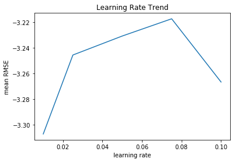

```python
sns.lineplot(x="param_learning_rate", y="mean_test_score", data=results3, color=current_palette[0])
plt.xlabel("learning rate")
plt.ylabel("mean RMSE")
plt.title("Learning Rate Trend")
```

From the learning rate plot, we can see that the RMSE is at its lowest when the learning rate is .075, which is the best learning rate parameter that was selected. This visual is helpful for validating the results above.

We can now redefine our gradient boosting model using the best parameters found above.

```python
#refit our gbm model using the best params above
gbm = GradientBoostingRegressor(n_estimators = 500, max_features = 'log2', max_depth = 5, criterion = 'mse', learning_rate = .075, random_state = RANDOM_SEED)
gbm.fit(X_train2, y_train2)
```

```
GradientBoostingRegressor(alpha=0.9, criterion='mse', init=None,
             learning_rate=0.075, loss='ls', max_depth=5,
             max_features='log2', max_leaf_nodes=None,
             min_impurity_decrease=0.0, min_impurity_split=None,
             min_samples_leaf=1, min_samples_split=2,
             min_weight_fraction_leaf=0.0, n_estimators=500,
             n_iter_no_change=None, presort='auto', random_state=42,
             subsample=1.0, tol=0.0001, validation_fraction=0.1, verbose=0,
             warm_start=False)
```

Like random forests, gradient boosting models also have the ability to extract feature importances. Therefore, we examine the feature importances from this model below.

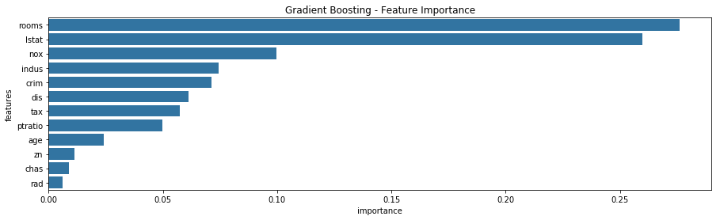

```python
feature_importances = pd.DataFrame(gbm.feature_importances_,
                                   index = X_train2.columns,
                                   columns=['importance']).sort_values('importance', ascending=False)
feature_importances['features'] = feature_importances.index

fig, axes = plt.subplots(nrows=1, ncols=1, figsize = (15,4))
sns.barplot(y = 'features', x = 'importance', data = feature_importances, color = current_palette[0])
plt.title('Gradient Boosting - Feature Importance')
```

We can see that like the random forest model, the average number of rooms (rooms) and socioeconomic status (lstat) are the two more important indicators for median home value. We can also see from this bar plot that these two variables have a much higher relative importance than other variables. In other words, it appears that these two variables are very important, since they are farther away from other predictors.

We can also see that there are some slight differences between this model and the random forest model on variable importances. For instance, the random forest model had rated the ptratio variable third in importance, while this model ranks it much lower. The indus, crim, and dis variables are near the top here, just like they are in the random forest model.

In contrast, access to radial highways, location on the Charles River, and percentage of land zoned do not appear to be important. Not surprisingly, from the exploratory data analysis performed, we know that these variables have fewer cases where these attributes are present.

Lastly, we calculate goodness of fit statistics for this model.

```python
#model evaluation
gbm_yhat = gbm.predict(X_train2)
gof_sum(gbm_yhat, y_train2, "Gradient Boosting", "Training Set")
```

```
+-------------------------------------------------------+
|                      Training Set                     |
+-------------------+-----------+-------+-------+-------+
|       Model       | R-Squared |  MSE  |  RMSE |  MAE  |
+-------------------+-----------+-------+-------+-------+
| Gradient Boosting |    1.0    | 0.002 | 0.048 | 0.036 |
+-------------------+-----------+-------+-------+-------+
```

Surprisingly, this model does really well. This model seems like it is overfitting the training set because of its high R-squared and low MSE, RMSE, and MAE results. We will be able to verify this hypothesis when examining the test set results and may need to readjust the hyperparameters.

# Model Selection

In this section, we evaluate the performance of our regression and tree-based methods on the test set. The model that has the best performance on the test set should be the model used by management in the future.

Of note, because the regression models were built on scaled data, their predictions are scaled back so that they can be readily compared against the predictions made by the tree-based methods.

```python
#generate test set predictions
lin_reg_yhat = scalery.inverse_transform(lin_reg.predict(X_test))
ridge_yhat = scalery.inverse_transform(ridge.predict(X_test))
lasso_yhat = scalery.inverse_transform(lasso.predict(X_test))
rf_yhat = rf.predict(X_test2)
gbm_yhat = gbm.predict(X_test2)
```

```python
gof_sum(lin_reg_yhat, scalery.inverse_transform(y_test), "Linear Regression", "Test Set")
gof_sum(ridge_yhat, scalery.inverse_transform(y_test), "Ridge Regression", "Test Set")
gof_sum(lasso_yhat, scalery.inverse_transform(y_test), "Lasso Regression", "Test Set")
gof_sum(rf_yhat, y_test2, "Random Forest", "Test Set")
gof_sum(gbm_yhat, y_test2, "Gradient Boosting", "Test Set")
```

```
+-------------------------------------------------------+
|                        Test Set                       |
+-------------------+-----------+--------+------+-------+
|       Model       | R-Squared |  MSE   | RMSE |  MAE  |
+-------------------+-----------+--------+------+-------+
| Linear Regression |   0.689   | 22.941 | 4.79 | 3.157 |
+-------------------+-----------+--------+------+-------+
+-------------------------------------------------------+
|                        Test Set                       |
+------------------+-----------+--------+-------+-------+
|      Model       | R-Squared |  MSE   |  RMSE |  MAE  |
+------------------+-----------+--------+-------+-------+
| Ridge Regression |   0.684   | 23.316 | 4.829 | 3.119 |
+------------------+-----------+--------+-------+-------+
+------------------------------------------------------+
|                       Test Set                       |
+------------------+-----------+--------+-------+------+
|      Model       | R-Squared |  MSE   |  RMSE | MAE  |
+------------------+-----------+--------+-------+------+
| Lasso Regression |   0.675   | 23.995 | 4.898 | 3.16 |
+------------------+-----------+--------+-------+------+
+----------------------------------------------------+
|                      Test Set                      |
+---------------+-----------+--------+-------+-------+
|     Model     | R-Squared |  MSE   |  RMSE |  MAE  |
+---------------+-----------+--------+-------+-------+
| Random Forest |   0.854   | 10.753 | 3.279 | 2.043 |
+---------------+-----------+--------+-------+-------+
+-------------------------------------------------------+
|                        Test Set                       |
+-------------------+-----------+-------+-------+-------+
|       Model       | R-Squared |  MSE  |  RMSE |  MAE  |
+-------------------+-----------+-------+-------+-------+
| Gradient Boosting |    0.89   | 8.113 | 2.848 | 1.846 |
+-------------------+-----------+-------+-------+-------+
```

From the goodness of fit statistics output above, we can readily see that the tree-based methods outperform the regression methods significantly. The tree-based methods have a higher R-squared value and lower MSE, RMSE, and MAE results.

Furthermore, we can see that the linear regression model outperforms the lasso and ridge regression models. This result is surprising. Because all variables have a small/medium effect on model performance, it seems like shrinking this impact from the ridge model has a worse impact on unseen data. With lasso, because there are no few predictors that greatly impact median home value, this model does not do as well.

As a final step, we examine the residuals for the Gradient Tree Boosting model.

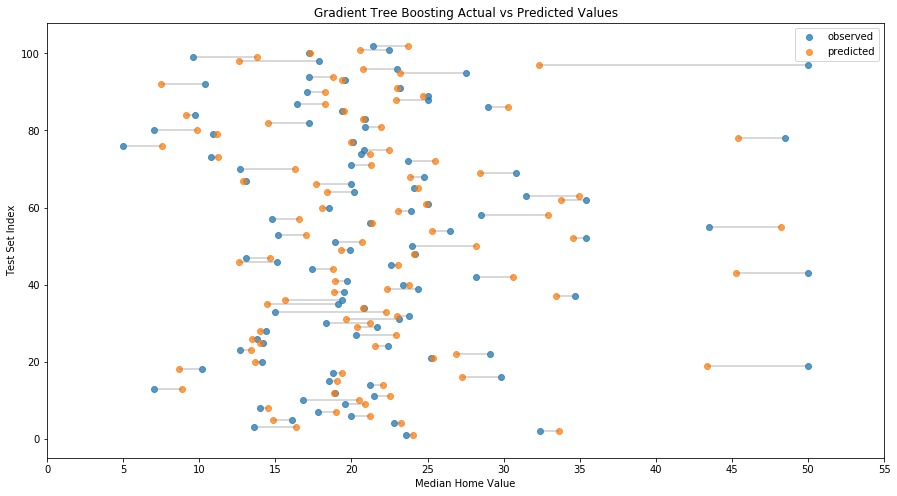

```python
#code from class
my_range=range(1,len(y_test2.index)+1)

plt.figure(figsize=(15, 8))
plt.hlines(y=my_range, xmin=y_test2, xmax=gbm_yhat, color='grey', alpha=0.4)
plt.scatter(y_test2, my_range, color=current_palette[0], alpha=.75, label='observed')
plt.scatter(gbm_yhat, my_range, color=current_palette[1], alpha=.75 , label='predicted')
plt.xlabel('Median Home Value')
plt.ylabel('Test Set Index')
plt.xticks(range(0,60,5))
plt.title("Gradient Tree Boosting Actual vs Predicted Values")
plt.legend(loc="best")
```

From this plot, we can better see that this model does a poor job of predicting homes with higher (>40) median home values. These results are consistent with the goodness of fit statistics observed above. Because RMSE is higher than MAE, we can see that there are some large residuals that are skewing results.

In short, more post-processing could be done to examine the residuals in greater detail and assess if removing large residuals (i.e., outliers or influential points) makes sense given the business goals.

# Summary and Conclusions

This analysis generated three different linear regression models and two tree-based models to predict median home value from the Boston housing data set. Both tree-based models ranked the variables of average rooms (rooms) and socioeconomic status (lstat) as important indicators for predicting median home value. The variables of location on the Charles River (chas), percent of land zoned for lots (zn), and access to radial highways (rad) appeared to have less impact on median home value, as they had low relative variable importance.

To help improve the fit of the model, there are several steps that could be considered:

- Inspect outliers and influential points. All observations were considered in this analysis, yet certain median home values may be outside the desired business range and if removed, could improve the fit of the final model. For instance, we saw above that the final model does a poor job of predicting higher (>40) median home values because there are so few of them. It may make sense to remove these homes altogether.
- Continue to test different tree-based models. While some hyperparameter tuning was done, even more hyperparameter tuning could be done to ensure that the final hyperparameters chosen are the best. Additionally, comparing models that remove unimportant predictors would be a helpful step to ensure that all predictors are needed to have the best predictions.
- Better understand business goals and ensure that the final model selected meets the business goals for explainability and predictive power.